# Data Management and Sharing Plans and the Role of Libraries

IS 262A guest lecture

Tim Dennis, UCLA Library

Jamie Jamison, UCLA Library

October 13, 2026

## Why data management plans matter

- Funders treat DMPs as proposal and reporting documents.
- Researchers get more value when they also use them as working plans.
- Good plans support reproducibility, ethical practice, and long-term reuse of the work.

> Plans change. Data, methods, collaborators, access conditions, and research questions shift over the life of a project. A DMP written once and filed away stops being useful.

## The research data lifecycle

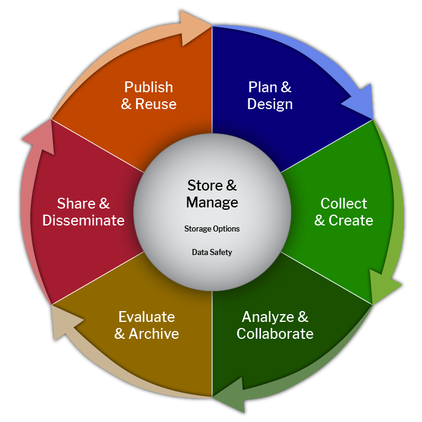

[Cioffi, Goldman & Marchese, Harvard, CC BY-NC 4.0](https://doi.org/10.5281/zenodo.8076168)

- Planning shapes every later stage, but a plan has to flex as the project moves through the cycle.
- The DMP is the connective document. It links what happens today to what happens after the grant ends.
- Notice “Store & Manage” sits at the center, not as one stage among others. Storage and data safety touch every phase, not just one step in the loop.

## Anatomy of a strong plan

| Section | What it covers |
| --- | --- |
| Data description | Types, formats, and approximate volume |
| Documentation | Metadata standards, READMEs, data dictionaries |
| Storage and backup | Where data live during the project, and how they’re protected |
| Sharing and access | Timelines, access conditions, and licensing or reuse terms |

| Section | What it covers |
| --- | --- |
| Consent and compliance | Privacy, consent, IRB, contractual, and legal constraints |
| Repository and preservation | Where data land long-term, and how they stay usable |
| Roles, retention, and cost | Who’s responsible, how long data are kept, and what it costs |

## Weak and strong plan language

**Sharing**

**Weak**

“Available upon request.”

**Strong**

“De-identified survey data will be published in UCLA Dataverse under an appropriate reuse license within six months of project end.”

**Storage**

**Weak**

“Data will be backed up regularly.”

**Strong**

“Data are stored on UCLA Box during the project, with version history retained, and archived to the department’s research storage at project close.”

## How librarians support researchers

- Review and strengthen DMP language before submission.
- Map funder and repository requirements to the specific project.
- Advise on metadata, formats, identifiers, and licensing.
- Point to campus infrastructure and services: UCLA Dataverse, Redivis, Merritt, and others.
- Identify issues that need referral, and connect researchers with IRB, privacy, information security, legal, contracts, or tribal authorities.

> Librarians usually identify and route compliance questions. They don’t make binding legal, IRB, security, or tribal-governance decisions themselves.

## The data interview

- Modeled on the reference interview, but focused on data.
- Ask early: what formats, what volume, how sensitive, who owns it.
- The answers shape both the plan and the project’s long-term access.

## Common problems and librarian interventions

- Vague or missing sharing statements → propose a specific repository, timeline, and license.
- Weak metadata and documentation → recommend a standard, a README template, a data dictionary.
- Unclear storage or backup strategy → separate “where data live” from “how they’re protected.”
- Unresolved ethics or consent questions → flag early, route to IRB or privacy office.
- Undefined roles → name who deposits, who maintains, who answers questions after the grant ends.

## Case: scraping Craigslist for housing data

[figure not shown]

- A project proposed collecting rental listings and landlord contact information to study post-incarceration housing access.
- Craigslist’s current terms prohibit automated or manual collection of its content without permission (craigslist, Inc. 2019).
- The plan also raised privacy and possible human-subjects questions.
- The team paused collection while it reconsidered its method and consulted the appropriate campus offices.

## Case: drone imagery over tribal land

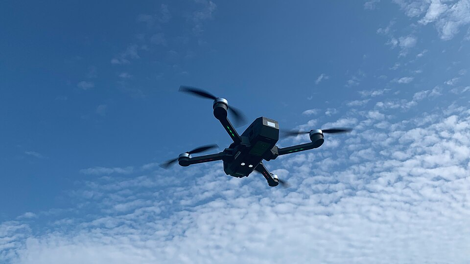

Quadcopter drone in flight. Photo by Project Kei, [CC BY-SA 4.0](https://creativecommons.org/licenses/by-sa/4.0/), via [Wikimedia Commons](https://commons.wikimedia.org/wiki/File:Quadcopter_Drone_in_flight.jpg).

- A project proposed depositing aerial imagery collected over tribal land in a public repository.
- The team recommended pausing the deposit while the researchers consulted the relevant tribal nation and appropriate campus experts.
- The CARE Principles for Indigenous Data Governance helped frame questions about collective benefit, authority to control, responsibility, and ethics.

## Case: linking voter and clinical data

[figure not shown]

Official ballot drop box, Washington, DC. Photo by Tony Webster, [CC BY 2.0](https://creativecommons.org/licenses/by/2.0/), via [Wikimedia Commons](https://commons.wikimedia.org/wiki/File:Official_Ballot_Drop_Box_-_District_of_Columbia_Elections_-_DC.jpg).

- A project combined purchased historical voter data (names, addresses) with clinical data from UCLA Health, held under restricted access.
- Linking identifiable voter records with clinical information changed the risk profile of the combined dataset.
- Review covered the data-use agreement, IRB protocol, consent and permitted uses, access controls, the approved computing environment, and the sharing and retention plan.

> Data linkage can make the combined dataset more sensitive than either source considered separately.

## A UCLA planning and review workflow

1. Researcher drafts a funder-specific plan.
2. Librarian reviews it and identifies questions or referrals.
3. Project staff implement the storage, documentation, access, and consent commitments.
4. The plan is updated as methods, data, collaborators, or restrictions change.
5. Data and related outputs are deposited, preserved, restricted, or disposed of as promised.
6. The project reports progress and changes to the funder.

[figure not shown]

## DMPTool demonstration

- Log in through UCLA’s institutional single sign-on.
- Open a current NIH or NSF template and show how institutional fields populate automatically.
- Show the ORCID connection: a registered plan gets a persistent DMP ID and can appear as a work on the creator’s ORCID record.
- Show where a plan can link to project outputs, such as a dataset or publication, once they exist.

## From a static document to a machine-actionable plan

- A conventional DMP is written mainly for a person to read.
- A machine-actionable DMP represents key facts in structured fields that systems can exchange, validate, and update: ORCID iDs, RORs, funder and award identifiers, DMP IDs, dataset DOIs, repository identifiers, licenses, access conditions, retention periods, and costs.

[figure not shown]

Example identifier chain (DataCite, n.d.; California Digital Library, n.d.-a)

> Machine-actionable doesn’t mean fully automated. Structured information can reduce repeated data entry and connect systems, but ethical decisions, consent restrictions, and repository suitability still need human judgment.

## Matching data with repositories and services

- **UCLA Dataverse**: citable data publication, with both open and restricted-file workflows (re3data.org, n.d.).
- **Dryad**: curated publication of openly shareable research data, no cost to UC researchers through UC’s institutional membership, and archived long-term through Merritt (California Digital Library, n.d.-b).
- **Redivis**: controlled-access data management and analysis platform, built for data with real privacy or governance constraints (Redivis, n.d.).
- **Merritt**: the UC system’s preservation repository, with account-based collections, a deposit interface, and an API. It also sits behind services such as Dryad (California Digital Library, n.d.-c).
- Domain repositories, identified through funder or disciplinary guidance, for data with a natural community home.

## Metadata, documentation, and persistent identifiers

- Descriptive and disciplinary metadata make a dataset findable and interpretable.
- READMEs, data dictionaries, and codebooks explain what’s inside and how it was produced.
- Version and provenance notes track how the data changed over time.
- Persistent identifiers such as DOIs, ORCID iDs, and RORs identify and resolve people, places, and things.

> A DOI identifies an object and resolves to information about it. It is one metadata element, not a substitute for descriptive metadata.

## Software gets its own treatment

- NSF’s sharing requirements include software. NIH’s DMS Policy covers scientific data, while separate NIH guidance encourages sharing research software.
- Some funders explicitly require software management planning, within a broader plan or as a separate Software Management Plan (SMP) (Software Sustainability Institute, n.d.).
- Give software the same three things data gets:
  - **License**: pick one before you publish, don’t leave it implicit.
  - **Identifier and citation**: a Zenodo DOI or a Software Heritage SWHID to identify it, and a `CITATION.cff` file (GitHub reads it natively) to say how to cite it.
  - **Documentation**: a README, a dependency list, enough context for someone else to rerun it.

## Takeaways, resources, and contact

- DMPs work best as living plans, not one-time paperwork.
- Librarians identify and route compliance questions. They don’t make binding legal, IRB, security, or tribal-governance decisions.
- Structured, machine-actionable plans connect systems, but human judgment still decides what’s ethical and appropriate.

**Resources:** [DMPTool](https://dmptool.org) · [UCLA Dataverse](https://dataverse.ucla.edu) · re3data.org · [FAIRsharing.org](https://fairsharing.org)

**Contact**  
Tim Dennis, Data Librarian (tdennis@library.ucla.edu)  
Jamie Jamison, Data Collections Manager (jamison@library.ucla.edu)  
Ashley Peterson, Digital Scholarship Librarian for the Arts & Humanities (ashleypeterson@library.ucla.edu)

Adapted from Library Carpentry *DMP101* (CC BY 4.0) (Bohman et al. 2025). 2025 version archived at doi.org/10.5281/zenodo.17360886 (Dennis and Jamison 2025).

## Glossary

**DMP**: Data Management Plan  
**DMSP / DMS Plan**: Data Management and Sharing Plan (NSF’s and NIH’s specific term for a DMP)  
**NSF**: National Science Foundation  
**NIH**: National Institutes of Health  
**IRB**: Institutional Review Board  
**DOI**: Digital Object Identifier, a persistent, resolvable ID for an object  
**ORCID**: a persistent ID for a person contributing to research, not an institution  
**ROR**: Research Organization Registry, a persistent ID for a research organization

**RDA**: Research Data Alliance  
**RPPR**: Research Performance Progress Report (an NIH reporting form)  
**FAIR**: Findable, Accessible, Interoperable, Reusable (data principles, not a synonym for “open”)  
**CARE**: Collective Benefit, Authority to Control, Responsibility, Ethics (Indigenous data governance)  
**maDMP**: machine-actionable DMP  
**SMP**: Software Management Plan  
**SWHID**: a Software Heritage identifier for a specific piece of archived code  
**CC BY / CC BY-NC**: Creative Commons license types. BY requires attribution; BY-NC also restricts commercial use.

## References

Barker, Michelle, Neil P. Chue Hong, Daniel S. Katz, et al. 2022. “Introducing the FAIR Principles for Research Software.” *Scientific Data* 9: 622. https://doi.org/10.1038/s41597-022-01710-x.

Bohman, Lena, Marla Hertz, and Daria Orlowska. 2025. *Data Management (and Sharing) Plans for Librarians 101*. Library Carpentry. https://librarycarpentry.org/lc-dmp101/.

California Digital Library. n.d.-a. *DMP IDs and Networked Data Management Plans (maDMPs)*. DMPTool. Accessed October 13, 2026. https://github.com/CDLUC3/dmptool/wiki/DMP-IDs-and-Networked-Data-Management-Plans-(maDMPs).

California Digital Library. n.d.-b. *Dryad*. Accessed October 13, 2026. https://cdlib.org/services/uc3/dryad/.

California Digital Library. n.d.-c. *Merritt*. Accessed October 13, 2026. https://cdlib.org/services/uc3/merritt/.

Cioffi, Matt, Julie Goldman, and Sarah Marchese. 2023. *Harvard Biomedical Research Data Lifecycle*. Zenodo. https://doi.org/10.5281/zenodo.8076168.

Citation File Format project. n.d. *Citation File Format (CFF)*. Accessed October 13, 2026. https://citation-file-format.github.io/.

CodeMeta Project. n.d. *The CodeMeta Project*. Accessed October 13, 2026. https://codemeta.github.io/.

craigslist, Inc. 2019. *Terms of Use*. https://www.craigslist.org/about/terms.of.use/en.

DataCite. n.d. *What Is a DMP ID?* Accessed October 13, 2026. https://support.datacite.org/docs/what-is-a-dmp-id.

Dennis, Tim, and Jamie Jamison. 2025. *Data Management Plans (DMP) and the Role of Libraries*. Zenodo. https://doi.org/10.5281/zenodo.17360886.

GitHub. n.d. *About CITATION Files*. GitHub Docs. Accessed October 13, 2026. https://docs.github.com/en/repositories/managing-your-repositorys-settings-and-features/customizing-your-repository/about-citation-files.

Grady, Becky, and Maria Praetzellis. 2026. *What Is the Future of Data Management Plans?* Upstream. https://doi.org/10.54900/fbq63-61s08.

National Institutes of Health. 2026a. *NOT-OD-26-046: Updated Elements of an NIH Data Management and Sharing Plan*. https://grants.nih.gov/grants/guide/notice-files/NOT-OD-26-046.html.

National Institutes of Health. 2026b. *NOT-OD-26-100: Implementation Update: NIH Data Management and Sharing Plan Requirements*. https://grants.nih.gov/grants/guide/notice-files/NOT-OD-26-100.html.

National Institutes of Health. 2026c. *NOT-OD-26-120: Accelerated Implementation of Data Management and Sharing Plan Changes for NIH Career Development (K) Awards*. https://grants.nih.gov/grants/guide/notice-files/NOT-OD-26-120.html.

National Science Foundation. 2026. *Policy Notice: Proposal and Award Policies and Procedures Guide (PAPPG) 24-1, Supplement 2 (NSF 26-202)*. https://www.nsf.gov/policies/document/pappg24-1-supplement-2.

OSTrails. 2026. *OSTrails Factsheet - Data Management Plan Interoperability Framework*. Zenodo. https://doi.org/10.5281/zenodo.19115854.

re3data.org. n.d. *UCLA Dataverse*. https://doi.org/10.17616/R3131H.

Redivis. n.d. *Redivis Documentation*. Accessed October 13, 2026. https://docs.redivis.com/.

Research Data Alliance DMP Common Standards Working Group. n.d. *RDA DMP Common Standard for Machine-Actionable Data Management Plans*. Accessed October 13, 2026. https://rda-dmp-common.github.io/RDA-DMP-Common-Standard/.

Software Heritage. 2026. *Software Heritage Archive Recognized as a Digital Public Good*. https://www.softwareheritage.org/2026/01/21/software-heritage-archive-digital-public-good/.

Software Sustainability Institute. n.d. *Writing and Using a Software Management Plan*. Accessed October 13, 2026. https://www.software.ac.uk/guide/writing-and-using-software-management-plan.

Zenodo. n.d. *Describe Software*. Accessed October 13, 2026. https://help.zenodo.org/docs/github/describe-software/.